# Covid_v8

## Corona Virus Data Analysis Insights Summary

### MSDS 422 Section 55

This analysis looks at the Corona virus data as of April 11th 2020 and finds that there is still significant risk of spread throughout the world population and that in several large countries (like the United States) death rates have not caught up with cases and there is a potential for a surge in deaths in the coming days.

The analysis looks at the data to gain insights into 2 key questions: 1) Does the data give any insight into the characteristics of the virus? 2) Does the data identify risk points where countries need to be focused?

1) Does the data give any insight into the characteristics of the virus?

The highest rate of infection, as seen in chart 3 (top 20 countries by cases per population) appear to be in the 2 to 10 people per thousand. Countries which have significant infection levels but are not yet in this range need to take precautions to avoid moving into that range and all countries need to ensure their medical systems can eventually handle a caseload equivalent to that. Because this is cumulative cases, case smoothing through social distancing endeavours may spread the infection rate at any one point in time out sufficiently to avoid overloading healthcare systems.

2) Does the data identify risk points where countries need to be focused? In terms of identifying risk, we looked at the data to answer the following 2 questions:

```
a) Are there countries which are below the current infection rate which migh be at risk?
```

The top 20 countries account for 89% of cases and 95% death. Unfortunately, some of the largest population countries in the world (India, Indonesia, Pakistan) do not show up on the list of countries with a high number of cases, which suggests that the cumulative number of cases worldwide may increase significantly should the virus take root and spread through these countries. The 3 listed countries are not countries known for having high quality and widely available healthcare, which increases the risk of catastrophic infection and death rates.

```
b) Are there countries which are trending higher on infection rate but lower on deaths?
```

Chart 4 shows that the United States stands out for being significantly lower on than the average on numbers of deaths vs numbers of cases, suggesting either a better than normal healthcare system or a need to prepare for an oncoming wave of fatalities. For most part, the other high infection rate countries are trending above the deaths per case average line.

```python
# Import modules
import pandas as pd
import numpy as np

import matplotlib as mpl
from matplotlib import pyplot as plt
from matplotlib import cm

import seaborn as sns

from sklearn import tree
from sklearn import preprocessing
from sklearn.metrics import accuracy_score
from sklearn.model_selection import StratifiedShuffleSplit

from sklearn.preprocessing import MinMaxScaler
from sklearn.preprocessing import minmax_scale
from sklearn.preprocessing import MaxAbsScaler
from sklearn.preprocessing import StandardScaler
from sklearn.preprocessing import RobustScaler
from sklearn.preprocessing import Normalizer
from sklearn.preprocessing import QuantileTransformer
from sklearn.preprocessing import PowerTransformer


# Read the data
data_raw = pd.read_csv('../covid/covid.csv')
```

```python
# Review the data to determine course of action.

data_raw.head()
```

|  | dateRep | day | month | year | cases | deaths | countriesAndTerritories | geoId | countryterritoryCode | popData2018 |
| --- | --- | --- | --- | --- | --- | --- | --- | --- | --- | --- |
| 0 | 11/04/2020 | 11 | 4 | 2020 | 37 | 0 | Afghanistan | AF | AFG | 37172386.0 |
| 1 | 10/04/2020 | 10 | 4 | 2020 | 61 | 1 | Afghanistan | AF | AFG | 37172386.0 |
| 2 | 09/04/2020 | 9 | 4 | 2020 | 56 | 3 | Afghanistan | AF | AFG | 37172386.0 |
| 3 | 08/04/2020 | 8 | 4 | 2020 | 30 | 4 | Afghanistan | AF | AFG | 37172386.0 |
| 4 | 07/04/2020 | 7 | 4 | 2020 | 38 | 0 | Afghanistan | AF | AFG | 37172386.0 |

### 1 & 2 Data Preparation and exploration

I combined data exploration and preparation as I continued to modify and massage data throughout the exploration, blurring the lines between data exploration and preparation. As I explored and identified new potential venues of investigation, I would go back to modify the data to support the new exploration.

In the first look at the data, it becomes obvious that the data is created in an additive manner, ie new data is added as it arrives. The first step is to add in a date field in date-time format and then sort the data by country into ascending date so that the data can be used as a time series

Review of null data shows that null records show up in geoId, ctycode and popData2018. Since we have country names we can ignore the ctycode and geoID as these can be engineered from the country names if needed. Of more concern is the missing population data. Further digging reveals that the records are focused on 5 countries: Anguilla (pop: 17400); Bonaire, Saint Eustatius and Saba (aka Carribean Netherlands, pop: 25,157); Czechia (new name of the Czech replublic, 10.6M); Eritrea (3.4M) ; and Falkland*Islands*(Malvinas) (pop:2,840) The null values were manually corrected to complete the data set.

The death rate growth number was also calculated as this allows us to calculate the velocity of the growth, not just raw growth (velocity is the growth rate of the speed). This allows us to tell if the speed of the virus spread is increasing or decreasing.

The cumulative death rate and case rate will allow us to look at the percent of the total population infected and killed by the virus. We can then chart in section 3 the mortality rate by country.

```python
# Data Clean and transform


# reduce unwieldy names and Review dataset with new names
df=pd.DataFrame(data_raw)
data=df.rename(columns={"countriesAndTerritories":"country","countryterritoryCode":"ctycode"})

#Add Country Number
from sklearn.preprocessing import OrdinalEncoder

df=pd.DataFrame(data)

country_cat=df[["country"]]
country_cat.head(10)

ordinal_encoder=OrdinalEncoder()
df['cty_num']=ordinal_encoder.fit_transform(country_cat)

#run this code if you waht to know what cty_num maps to: >>>ordinal_encoder.categories_

#Create Data Frame for further cleansing/modification
df=pd.DataFrame(data)

# Create a date field in datetime Data type
df['date']=pd.to_datetime(df['dateRep'],dayfirst=True)

# Sort data by country and then by date
df["cnty"]=df["country"]
df["dte"]=df["date"]
df=df.sort_values(["country", "date"], ascending = (True, True))

# Create Index with country and date
df["cnty"]=df["cty_num"]
df["dte"]=df["date"]
df.set_index(['cnty','dte'], inplace=True, append=True, drop=True)

#Load data into a table
data=df

#Check New Data, verify that the data is sorted properly and that all the fields are of the correct type
data.info()
data.head()
```

```
<class 'pandas.core.frame.DataFrame'>
MultiIndex: 10127 entries, (92, 0.0, Timestamp('2019-12-31 00:00:00')) to (10105, 205.0, Timestamp('2020-04-11 00:00:00'))
Data columns (total 12 columns):
 #   Column       Non-Null Count  Dtype
---  ------       --------------  -----
 0   dateRep      10127 non-null  object
 1   day          10127 non-null  int64
 2   month        10127 non-null  int64
 3   year         10127 non-null  int64
 4   cases        10127 non-null  int64
 5   deaths       10127 non-null  int64
 6   country      10127 non-null  object
 7   geoId        10099 non-null  object
 8   ctycode      9926 non-null   object
 9   popData2018  9969 non-null   float64
 10  cty_num      10127 non-null  float64
 11  date         10127 non-null  datetime64[ns]
dtypes: datetime64[ns](1), float64(2), int64(5), object(4)
memory usage: 1.1+ MB
```

|  | cnty | dte | dateRep | day | month | year | cases | deaths | country | geoId | ctycode | popData2018 | cty_num | date |
| --- | --- | --- | --- | --- | --- | --- | --- | --- | --- | --- | --- | --- | --- | --- |
| 92 | 0.0 | 2019-12-31 | 31/12/2019 | 31 | 12 | 2019 | 0 | 0 | Afghanistan | AF | AFG | 37172386.0 | 0.0 | 2019-12-31 |
| 91 | 0.0 | 2020-01-01 | 01/01/2020 | 1 | 1 | 2020 | 0 | 0 | Afghanistan | AF | AFG | 37172386.0 | 0.0 | 2020-01-01 |
| 90 | 0.0 | 2020-01-02 | 02/01/2020 | 2 | 1 | 2020 | 0 | 0 | Afghanistan | AF | AFG | 37172386.0 | 0.0 | 2020-01-02 |
| 89 | 0.0 | 2020-01-03 | 03/01/2020 | 3 | 1 | 2020 | 0 | 0 | Afghanistan | AF | AFG | 37172386.0 | 0.0 | 2020-01-03 |
| 88 | 0.0 | 2020-01-04 | 04/01/2020 | 4 | 1 | 2020 | 0 | 0 | Afghanistan | AF | AFG | 37172386.0 | 0.0 | 2020-01-04 |

```python
# 1b Check for null values
# yes there are null values in 5 columns

df2=pd.DataFrame(data)
null_columns=df2.columns[df2.isnull().any()]
print('Columns with null values:\n',df2[null_columns].isnull().sum())
print("-"*20)

# Are numbers of null values signficant?
# No, ctycode and geoID are based on Country, so we can just use country and country number (cty_num) insted of GEOID
# Population data is missing 1.5% of records.
# 5 countries have no popultaiton data, but these are small countries so we can ignore.

null_percent=(((df2[null_columns].isnull().sum())/((df2[null_columns].isnull().sum())+(df2[null_columns].count())))*100)
print('Percent null values:\n',null_percent)

# Print List of countries with no popData2018
print("-"*20)
print('Countries with no population data in 2018')
gdf2=(df2[df2["popData2018"].isnull()])
gdf2.groupby(['country']).count()
```

```
Columns with null values:
 geoId           28
ctycode        201
popData2018    158
dtype: int64
--------------------
Percent null values:
 geoId          0.276489
ctycode        1.984793
popData2018    1.560186
dtype: float64
--------------------
Countries with no population data in 2018
```

| country | dateRep | day | month | year | cases | deaths | geoId | ctycode | popData2018 | cty_num | date |
| --- | --- | --- | --- | --- | --- | --- | --- | --- | --- | --- | --- |
| Anguilla | 16 | 16 | 16 | 16 | 16 | 16 | 16 | 0 | 0 | 16 | 16 |
| Bonaire, Saint Eustatius and Saba | 10 | 10 | 10 | 10 | 10 | 10 | 10 | 0 | 0 | 10 | 10 |
| Czechia | 103 | 103 | 103 | 103 | 103 | 103 | 103 | 0 | 0 | 103 | 103 |
| Eritrea | 21 | 21 | 21 | 21 | 21 | 21 | 21 | 21 | 0 | 21 | 21 |
| Falkland_Islands_(Malvinas) | 8 | 8 | 8 | 8 | 8 | 8 | 8 | 0 | 0 | 8 | 8 |

```python
# 1c Populate missing population numbers and check

df=pd.DataFrame(data)
df.loc[df['country'] == 'Anguilla', 'popData2018' ] = 17400
df.loc[df['country'] == 'Bonaire, Saint Eustatius and Saba', 'popData2018' ] = 25157
df.loc[df['country'] == 'Czechia', 'popData2018' ] = 10665677
df.loc[df['country'] == 'Eritrea', 'popData2018' ] = 3452786
df.loc[df['country'] == 'Falkland_Islands_(Malvinas)', 'popData2018' ] = 2840

data=df

df.loc[df['country'] == 'Anguilla']
df.loc[df['country'] == 'Bonaire, Saint Eustatius and Saba']
df.loc[df['country'] == 'Czechia']
df.loc[df['country'] == 'Eritrea']
df.loc[df['country'] == 'Falkland_Islands_(Malvinas)']

null_percent=(((df2[null_columns].isnull().sum())/((df2[null_columns].isnull().sum())+(df2[null_columns].count())))*100)
print('Percent null values:\n',null_percent)

# Print List of countries with no popData2018
# If it returns no results, then all data populated

print("-"*20)
print('Countries with no population data in 2018')
gdf2=(df2[df2["popData2018"].isnull()])
gdf2.groupby(['country']).count()
```

```
Percent null values:
 geoId          0.276489
ctycode        1.984793
popData2018    0.000000
dtype: float64
--------------------
Countries with no population data in 2018
```

|  | dateRep | day | month | year | cases | deaths | geoId | ctycode | popData2018 | cty_num | date |
| --- | --- | --- | --- | --- | --- | --- | --- | --- | --- | --- | --- |
| country |  |  |  |  |  |  |  |  |  |  |  |

```python
# Calculate rate of growth of cases and deaths
df=pd.DataFrame(data)
df['case_growth']=df['cases'].groupby(level='cnty').diff()
df['death_growth']=df['deaths'].groupby(level='cnty').diff()

# Replace Nulls with 0
df['case_growth']=df['case_growth'].fillna(0)
df['death_growth']=df['death_growth'].fillna(0)

data=df

# Check that fields have been created correctly
# look at rows 90-95, thats where country changes. Ensure that growth calculators reset by country.
data.info()
data.iloc[90:95]
```

```
<class 'pandas.core.frame.DataFrame'>
MultiIndex: 10127 entries, (92, 0.0, Timestamp('2019-12-31 00:00:00')) to (10105, 205.0, Timestamp('2020-04-11 00:00:00'))
Data columns (total 14 columns):
 #   Column        Non-Null Count  Dtype
---  ------        --------------  -----
 0   dateRep       10127 non-null  object
 1   day           10127 non-null  int64
 2   month         10127 non-null  int64
 3   year          10127 non-null  int64
 4   cases         10127 non-null  int64
 5   deaths        10127 non-null  int64
 6   country       10127 non-null  object
 7   geoId         10099 non-null  object
 8   ctycode       9926 non-null   object
 9   popData2018   10127 non-null  float64
 10  cty_num       10127 non-null  float64
 11  date          10127 non-null  datetime64[ns]
 12  case_growth   10127 non-null  float64
 13  death_growth  10127 non-null  float64
dtypes: datetime64[ns](1), float64(4), int64(5), object(4)
memory usage: 1.5+ MB
```

|  | cnty | dte | dateRep | day | month | year | cases | deaths | country | geoId | ctycode | popData2018 | cty_num | date | case_growth | death_growth |
| --- | --- | --- | --- | --- | --- | --- | --- | --- | --- | --- | --- | --- | --- | --- | --- | --- |
| 2 | 0.0 | 2020-04-09 | 09/04/2020 | 9 | 4 | 2020 | 56 | 3 | Afghanistan | AF | AFG | 37172386.0 | 0.0 | 2020-04-09 | 26.0 | -1.0 |
| 1 | 0.0 | 2020-04-10 | 10/04/2020 | 10 | 4 | 2020 | 61 | 1 | Afghanistan | AF | AFG | 37172386.0 | 0.0 | 2020-04-10 | 5.0 | -2.0 |
| 0 | 0.0 | 2020-04-11 | 11/04/2020 | 11 | 4 | 2020 | 37 | 0 | Afghanistan | AF | AFG | 37172386.0 | 0.0 | 2020-04-11 | -24.0 | -1.0 |
| 126 | 1.0 | 2020-03-09 | 09/03/2020 | 9 | 3 | 2020 | 2 | 0 | Albania | AL | ALB | 2866376.0 | 1.0 | 2020-03-09 | 0.0 | 0.0 |
| 125 | 1.0 | 2020-03-10 | 10/03/2020 | 10 | 3 | 2020 | 4 | 0 | Albania | AL | ALB | 2866376.0 | 1.0 | 2020-03-10 | 2.0 | 0.0 |

```python
# Add Cumulative cases and deaths

df=pd.DataFrame(data)
df['cum_cases'] = df['cases'].groupby(by=['cnty']).cumsum()
df['cum_deaths'] = df['deaths'].groupby(by=['cnty']).cumsum()

data=df
data.iloc[90:95]
```

|  | cnty | dte | dateRep | day | month | year | cases | deaths | country | geoId | ctycode | popData2018 | cty_num | date | case_growth | death_growth | cum_cases | cum_deaths |
| --- | --- | --- | --- | --- | --- | --- | --- | --- | --- | --- | --- | --- | --- | --- | --- | --- | --- | --- |
| 2 | 0.0 | 2020-04-09 | 09/04/2020 | 9 | 4 | 2020 | 56 | 3 | Afghanistan | AF | AFG | 37172386.0 | 0.0 | 2020-04-09 | 26.0 | -1.0 | 423 | 14 |
| 1 | 0.0 | 2020-04-10 | 10/04/2020 | 10 | 4 | 2020 | 61 | 1 | Afghanistan | AF | AFG | 37172386.0 | 0.0 | 2020-04-10 | 5.0 | -2.0 | 484 | 15 |
| 0 | 0.0 | 2020-04-11 | 11/04/2020 | 11 | 4 | 2020 | 37 | 0 | Afghanistan | AF | AFG | 37172386.0 | 0.0 | 2020-04-11 | -24.0 | -1.0 | 521 | 15 |
| 126 | 1.0 | 2020-03-09 | 09/03/2020 | 9 | 3 | 2020 | 2 | 0 | Albania | AL | ALB | 2866376.0 | 1.0 | 2020-03-09 | 0.0 | 0.0 | 2 | 0 |
| 125 | 1.0 | 2020-03-10 | 10/03/2020 | 10 | 3 | 2020 | 4 | 0 | Albania | AL | ALB | 2866376.0 | 1.0 | 2020-03-10 | 2.0 | 0.0 | 6 | 0 |

```python
# Add cases and deaths as percent of population
# Add deaths as percent of cases

df=pd.DataFrame(data)

df['case_pct_pop']=df['cum_cases']/df['popData2018']
df['deaths_pct_pop']=df['cum_deaths']/df['popData2018']
df['deaths_per_case']=df['cum_deaths']/df['cum_cases']

df['case_pct_pop']=df['case_pct_pop'].fillna(0)
df['deaths_pct_pop']=df['deaths_pct_pop'].fillna(0)
df['deaths_per_case']=df['deaths_per_case'].fillna(0)


data=df
```

```python
# Check Final Transformed Data Set

df=pd.DataFrame(data)
df.head()
```

|  | cnty | dte | dateRep | day | month | year | cases | deaths | country | geoId | ctycode | popData2018 | cty_num | date | case_growth | death_growth | cum_cases | cum_deaths | case_pct_pop | deaths_pct_pop | deaths_per_case |
| --- | --- | --- | --- | --- | --- | --- | --- | --- | --- | --- | --- | --- | --- | --- | --- | --- | --- | --- | --- | --- | --- |
| 92 | 0.0 | 2019-12-31 | 31/12/2019 | 31 | 12 | 2019 | 0 | 0 | Afghanistan | AF | AFG | 37172386.0 | 0.0 | 2019-12-31 | 0.0 | 0.0 | 0 | 0 | 0.0 | 0.0 | 0.0 |
| 91 | 0.0 | 2020-01-01 | 01/01/2020 | 1 | 1 | 2020 | 0 | 0 | Afghanistan | AF | AFG | 37172386.0 | 0.0 | 2020-01-01 | 0.0 | 0.0 | 0 | 0 | 0.0 | 0.0 | 0.0 |
| 90 | 0.0 | 2020-01-02 | 02/01/2020 | 2 | 1 | 2020 | 0 | 0 | Afghanistan | AF | AFG | 37172386.0 | 0.0 | 2020-01-02 | 0.0 | 0.0 | 0 | 0 | 0.0 | 0.0 | 0.0 |
| 89 | 0.0 | 2020-01-03 | 03/01/2020 | 3 | 1 | 2020 | 0 | 0 | Afghanistan | AF | AFG | 37172386.0 | 0.0 | 2020-01-03 | 0.0 | 0.0 | 0 | 0 | 0.0 | 0.0 | 0.0 |
| 88 | 0.0 | 2020-01-04 | 04/01/2020 | 4 | 1 | 2020 | 0 | 0 | Afghanistan | AF | AFG | 37172386.0 | 0.0 | 2020-01-04 | 0.0 | 0.0 | 0 | 0 | 0.0 | 0.0 | 0.0 |

```python
# Number of unique countries
# data shows that there are 206 countries in the dataset
# This is too large a number to easily view

df=pd.DataFrame(data)
df['country'].nunique()
print('Number of countries:',df['country'].nunique())
```

```
Number of countries: 206
```

```python
# The top 20 countries by cases, based on cumulative cases at the last date of the dataset
# The top 20 coutnries by cases make up 89% of all cases

df_casesum=df.groupby(['country'], sort=False)['cum_cases'].max().reset_index()
df_casesum=df_casesum.sort_values(['cum_cases'], ascending = (False))
top20case=df_casesum.nlargest(20,'cum_cases')
print(top20case)

print("-"*20)

total_top20=top20case['cum_cases'].sum()
print ('total cases top 20:',total_top20)

total_all=df_casesum['cum_cases'].sum()
print ('total cases all:',total_all)

top20percent=total_top20/total_all
print ('total 20 as percent of all:',round(top20percent,2))
```

```
                      country  cum_cases
198  United_States_of_America     501560
177                     Spain     157022
98                      Italy     147577
74                    Germany     117658
69                     France      90676
42                      China      83004
195            United_Kingdom      70272
93                       Iran      68192
190                    Turkey      47029
18                    Belgium      26667
182               Switzerland      24228
135               Netherlands      23097
35                     Canada      22133
27                     Brazil      19638
153                  Portugal      15472
11                    Austria      13560
157                    Russia      11917
175               South_Korea      10450
97                     Israel      10408
181                    Sweden       9685
--------------------
total cases top 20: 1470245
total cases all: 1653213
total 20 as percent of all: 0.89
```

```python
# The top 20 countries by deaths
# This is derived by taking the max number of deaths in the country throughout the entire date range
# The top 20 by deaths make up 95% of all deaths

df_deathsum=df.groupby(['country'], sort=False)['cum_deaths'].max().reset_index()
df_deathsum=df_deathsum.sort_values(['cum_deaths'], ascending = (False))
top20deaths=df_deathsum.nlargest(20,'cum_deaths')
print(top20deaths)

print("-"*20)

total_top20=top20deaths['cum_deaths'].sum()
print ('total deaths top 20:',total_top20)

total_all=df_deathsum['cum_deaths'].sum()
print ('total deaths all:',total_all)

top20percent=total_top20/total_all
print ('total 20 as percent of all:',round(top20percent,2))
```

```
                      country  cum_deaths
98                      Italy       18851
198  United_States_of_America       18777
177                     Spain       15843
69                     France       13197
195            United_Kingdom        8958
93                       Iran        4232
42                      China        3343
18                    Belgium        3019
74                    Germany        2544
135               Netherlands        2511
27                     Brazil        1056
190                    Turkey        1006
181                    Sweden         870
182               Switzerland         805
35                     Canada         569
153                  Portugal         435
11                    Austria         319
92                  Indonesia         306
57                    Ecuador         297
95                    Ireland         287
--------------------
total deaths top 20: 97225
total deaths all: 102088
total 20 as percent of all: 0.95
```

```python
# current top 20 countries deaths as a percent of cases

df=pd.DataFrame(data)
df_dthPerCase=df.loc[df.groupby(["cnty"])["date"].idxmax()]
df_dthPerCase=df_dthPerCase.sort_values(["deaths_per_case","country"], ascending = (False, True))

top20deathrate=df_dthPerCase.nlargest(20,'deaths_per_case')
print(top20deathrate)
```

```
                           dateRep  day  month  year  cases  deaths  \
      cnty  dte
10105 205.0 2020-04-11  11/04/2020   11      4  2020      0       0
3479  72.0  2020-04-11  11/04/2020   11      4  2020      0       0
1144  19.0  2020-04-11  11/04/2020   11      4  2020      1       1
766   13.0  2020-04-11  11/04/2020   11      4  2020      1       0
7012  142.0 2020-04-11  11/04/2020   11      4  2020      0       0
8408  170.0 2020-04-11  11/04/2020   11      4  2020      0       1
6780  138.0 2020-04-11  11/04/2020   11      4  2020      0       0
4022  85.0  2020-04-11  11/04/2020   11      4  2020      3       0
3323  69.0  2020-04-11  11/04/2020   11      4  2020   4342     987
127   2.0   2020-04-11  11/04/2020   11      4  2020     95      21
1771  36.0  2020-04-11  11/04/2020   11      4  2020      0       0
6027  122.0 2020-04-11  11/04/2020   11      4  2020      0       0
8864  179.0 2020-04-11  11/04/2020   11      4  2020      1       0
```

[output cut: 99 more lines]

### 3. Data Visualization

Chart 1, cases by month, shows the sharp difference between China and the rest of the world. While China's cases have flatlined, the rest of the world continues to grow. The sharp rise of United States cases is particularly concerning. Chart 2, deaths per month, shows the death rate mirroring the infection rate. This is studied in more detail in the following charts.

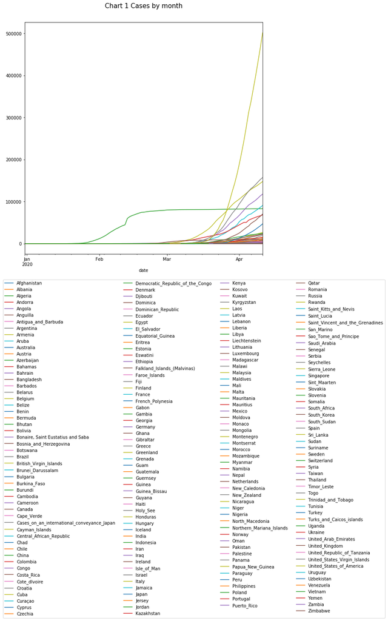

```python
# Cumulative cases by month


df=pd.DataFrame(data)
case_growth_chart=df.pivot(index='date',columns='country',values='cum_cases')
case_growth_chart.plot()

plt.title('Chart 1 Cases by month', y=1.05, size=15)
plt.legend(loc='upper left', bbox_to_anchor=(-0.1, -0.1), ncol=4)
plt.rcParams["figure.figsize"] = [10,10]
```

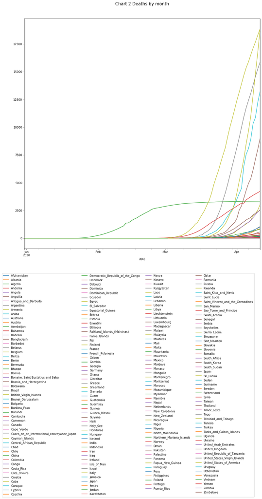

```python
# Cumulative deaths by month
# This chart shows the shrap difference between US and the rest of the world when looking at deaths. It suggests that
# fatalities still have a way to go to hitting the global average. The deaths per case chart will illustrate this more clearly.

df=pd.DataFrame(data)
case_growth_chart=df.pivot(index='date',columns='country',values='cum_deaths')
case_growth_chart.plot()

plt.title('Chart 2 Deaths by month', y=1.05, size=15)
plt.legend(loc='upper left', bbox_to_anchor=(-0.1, -0.1), ncol=4)
plt.rcParams["figure.figsize"] = [10,10]
```

```
                         country  case_pct_pop
162                   San_Marino      0.010182
87                      Holy_See      0.008000
3                        Andorra      0.007805
115                   Luxembourg      0.005303
90                       Iceland      0.004737
66                 Faroe_Islands      0.003794
76                     Gibraltar      0.003767
177                        Spain      0.003361
82                      Guernsey      0.003173
182                  Switzerland      0.002845
98                         Italy      0.002442
96                   Isle_of_Man      0.002391
18                       Belgium      0.002335
126                       Monaco      0.002327
113                Liechtenstein      0.002110
101                       Jersey      0.001854
65   Falkland_Islands_(Malvinas)      0.001761
95                       Ireland      0.001667
198     United_States_of_America      0.001533
--------------------
```

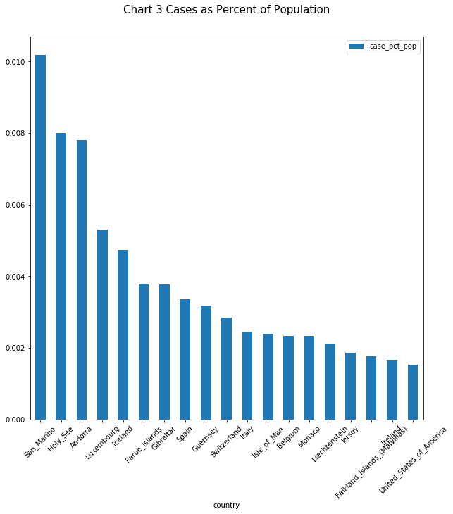

```python
# Total Cases as a percent of population
# The cases per population shows us what kind of infection rates we might expect at the top end of the range. It also shows that
# some of the larger countries in the world with lower infection rates could see significant infections if protective measures
# are not taken they start to close in on some of these high infection scenario countries


df=pd.DataFrame(data)

# This code groups the data by country and then takes the max of cases as a precent of populatoin by country. This give us the
# max infection rate of every country thus far and allows us to plot the highest potential infection rates.

df_casespctpop=df.groupby(['country'], sort=False)['case_pct_pop'].max().reset_index()
top20rate=df_casespctpop.nlargest(20,'case_pct_pop')
top20rate_clean=top20rate[top20rate.country !='Cases_on_an_international_conveyance_Japan']


print(top20rate_clean)
print("-"*20)


ax = top20rate_clean.plot.bar(x='country', y='case_pct_pop', rot=0)
plt.xticks(rotation=45)
plt.title('Chart 3 Cases as Percent of Population', y=1.05, size=15)
```

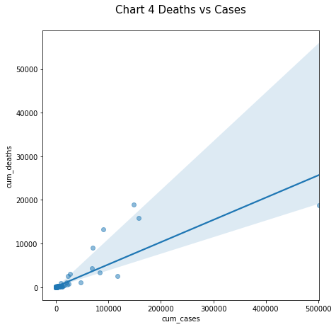

```python
# Deaths vs cases
# When comparing cases vs deaths it appears that the USA is tracking below the regression line, which is either an indication
# of a better medical system, healthier population (or combination of both) or impending increase in deaths to bring the
# deathrate closer to the norm.It should slo be noted that above 50,000 cases, the death rate to cases becomes highly
# unpredictable with current data, with most of the cases falling outside the confidence range.
# I experimeted with taken the log of the axes and utilizing a log scale on the X-axis appeared to bring the data points closest
# to the regression line and the confidence interval. This seems to suggest that the log of cases is a potential predictor of Y.


df=pd.DataFrame(data)

# This code groups the data by country and then take the max of the index (in this case date and country) to give the data
# for the latest date.
df_latestdata=df.loc[df.groupby(["cnty"])["date"].idxmax()]
df_casevsdeath=df_latestdata[["cum_cases","cum_deaths"]].copy()
casevsdeath=df_casevsdeath

# Plot figure using pyplot
f, ax = plt.subplots(figsize=(7, 7))
sns.regplot(x='cum_cases', y='cum_deaths', data=casevsdeath, fit_reg=True, scatter_kws={'alpha':0.5})

plt.title('Chart 4 Deaths vs Cases', y=1.05, size=15)
```

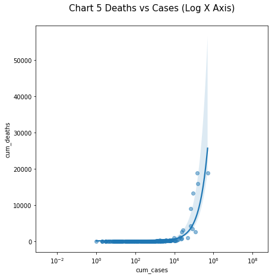

```python
# Chart 5 takes the log on the X axis and the data points are a lot closer suggesting that a logarithmic algorithm
# would generate a better predictive formula.

f, ax = plt.subplots(figsize=(7, 7))
#ax.set(xscale="log", yscale="log")
#ax.set(yscale="log")
ax.set(xscale="log")
sns.regplot(x='cum_cases', y='cum_deaths', data=casevsdeath, fit_reg=True, scatter_kws={'alpha':0.5})
plt.title('Chart 5 Deaths vs Cases (Log X Axis)', y=1.05, size=15)
```

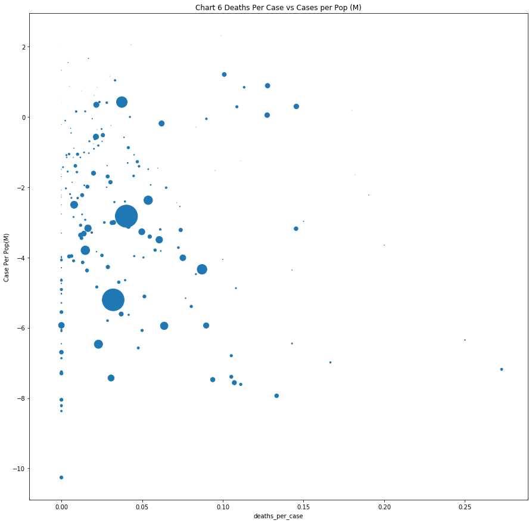

```python
# Deaths per case vs Cases per population with country population for marker size

# This chart indicates several things:
# 1) The death rate per case appears to be around 0.03 per case or 3% of confirmed cases. (This lines up with published info)
# 2) There are significant outliers which suggests either poor healthcare or lack of testing in some countries.
#    - If we llok at trends and see the death rate climbing over time, it could suggest a mutation to kae the virus deadlier
# 3) There are a lot of large population countries with lower cases per population. These countries need to start taking
#    precautions now to prevent a large outbreak.

df=pd.DataFrame(data)
df_latestdata=df.loc[df.groupby(["cnty"])["date"].idxmax()]
df_chartdata=df_latestdata[["country","deaths_per_case","cum_cases","popData2018"]].copy()
df_chartdata["PopM"]=(df_chartdata["popData2018"]/1000000)
df_chartdata["CasePerKPop"]=(df_chartdata["cum_cases"]/(df_chartdata["popData2018"]/1000))
df_chartdata=df_chartdata[df_chartdata.country !='Cases_on_an_international_conveyance_Japan']
chartdata=df_chartdata

x = (chartdata["deaths_per_case"])
y = np.log(chartdata["CasePerKPop"], dtype='float64')
s = chartdata["PopM"]

plt.scatter(x,y,s)
plt.title("Chart 6 Deaths Per Case vs Cases per Pop (M)")
plt.xlabel("deaths_per_case")
plt.ylabel("Case Per Pop(M)")
```

### 4. Data Scaling

For the purpose of the data scaling exercise, we will continue the scaling exercise started in the cases vs deaths chart. For this exercise, we use 4 scalers to transform the data. Standard Scaler Normalizer Min Max Scaler Max Abs Scaler

None of the scaling appears to have generated a regression that improved over the log of cumulative cases approach taken in the charting section.

```python
import numpy as np

import matplotlib as mpl
from matplotlib import pyplot as plt
from matplotlib import cm

from sklearn.preprocessing import MinMaxScaler
from sklearn.preprocessing import minmax_scale
from sklearn.preprocessing import MaxAbsScaler
from sklearn.preprocessing import StandardScaler
from sklearn.preprocessing import RobustScaler
from sklearn.preprocessing import Normalizer
from sklearn.preprocessing import QuantileTransformer
from sklearn.preprocessing import PowerTransformer
```

```
StandardScaler(copy=True, with_mean=True, with_std=True)
[8025.26213592  495.57281553]
```

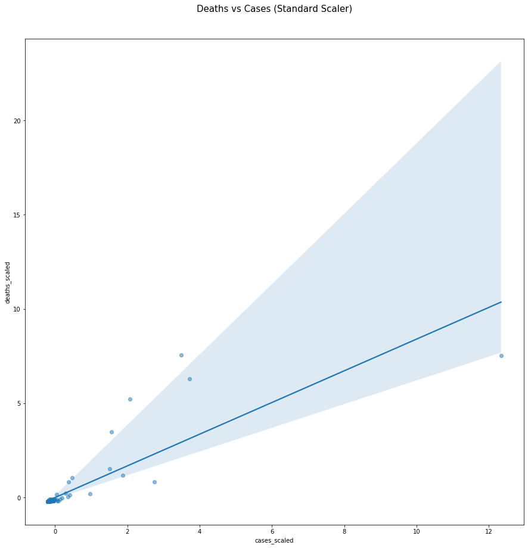

```python
# Standard Scaler

df=pd.DataFrame(data)
df_latestdata=df.loc[df.groupby(["cnty"])["date"].idxmax()]
df_casevsdeath=df_latestdata[["cum_cases","cum_deaths"]].copy()

X = df_casevsdeath.copy()
scaler = StandardScaler()
print(scaler.fit(X))
StandardScaler()
print(scaler.mean_)
ScaledData=(scaler.transform(X))

df_ScaledChart=pd.DataFrame(ScaledData, columns=['cases_scaled','deaths_scaled'])

sns.regplot(x='cases_scaled', y='deaths_scaled', data=df_ScaledChart, fit_reg=True, scatter_kws={'alpha':0.5})
plt.title('Deaths vs Cases (Standard Scaler)', y=1.05, size=15)
```

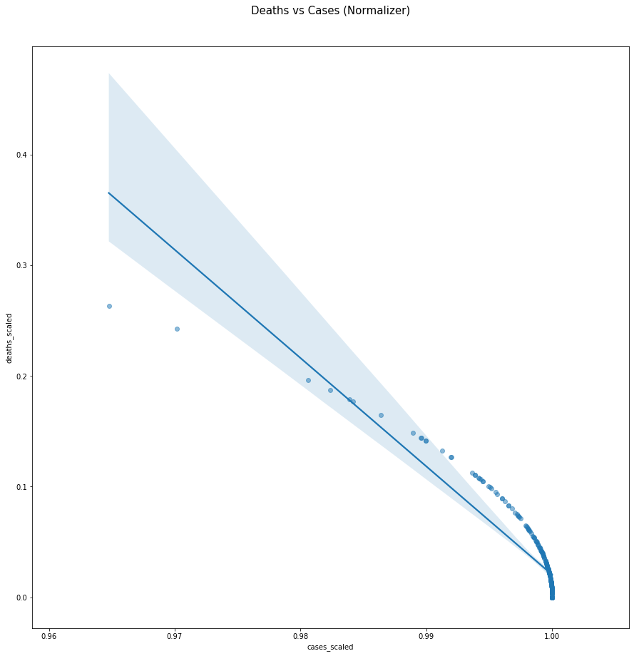

```python
# Normalizer Scaler

df=pd.DataFrame(data)
df_latestdata=df.loc[df.groupby(["cnty"])["date"].idxmax()]
df_casevsdeath=df_latestdata[["cum_cases","cum_deaths"]].copy()

X = df_casevsdeath.copy()
transformer = Normalizer().fit(X)  # fit does nothing.
transformer
Normalizer()
ScaledData=transformer.transform(X)
df_NormChart=pd.DataFrame(ScaledData, columns=['cases_scaled','deaths_scaled'])

sns.regplot(x='cases_scaled', y='deaths_scaled', data=df_NormChart, fit_reg=True, scatter_kws={'alpha':0.5})
plt.title('Deaths vs Cases (Normalizer)', y=1.05, size=15)
```

```
MinMaxScaler(copy=True, feature_range=(0, 1))
[501560.  18851.]
```

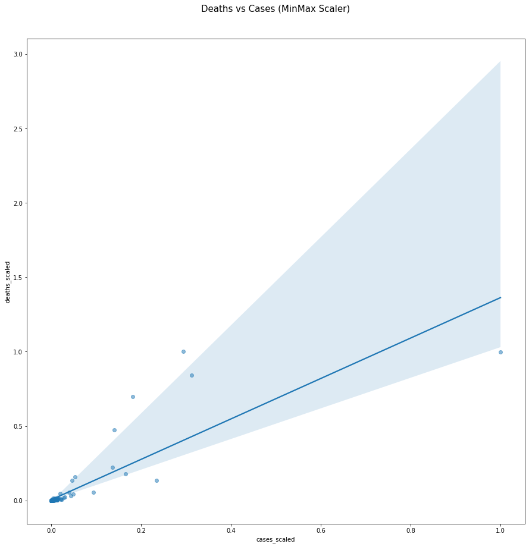

```python
# Min Max Scaler

df=pd.DataFrame(data)
df_latestdata=df.loc[df.groupby(["cnty"])["date"].idxmax()]
df_casevsdeath=df_latestdata[["cum_cases","cum_deaths"]].copy()

X = df_casevsdeath.copy()
scaler = MinMaxScaler()
print(scaler.fit(X))
MinMaxScaler()
print(scaler.data_max_)
MinMaxScaledData=(scaler.transform(X))
df_MinMaxChart=pd.DataFrame(MinMaxScaledData, columns=['cases_scaled','deaths_scaled'])

sns.regplot(x='cases_scaled', y='deaths_scaled', data=df_MinMaxChart, fit_reg=True, scatter_kws={'alpha':0.5})
plt.title('Deaths vs Cases (MinMax Scaler)', y=1.05, size=15)
```

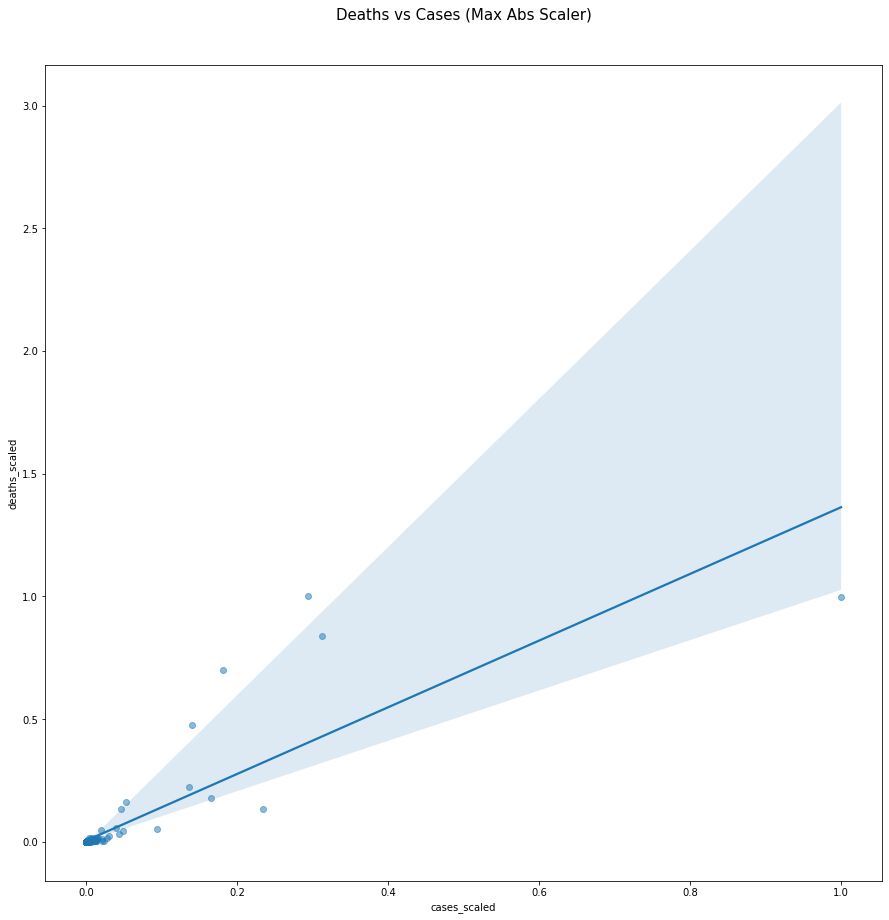

```python
# MaxAbs Scaler

df=pd.DataFrame(data)
df_latestdata=df.loc[df.groupby(["cnty"])["date"].idxmax()]
df_casevsdeath=df_latestdata[["cum_cases","cum_deaths"]].copy()

X = df_casevsdeath.copy()
transformer =MaxAbsScaler().fit(X)
transformer
MaxScaledData=transformer.transform(X)
df_MaxAbsChart=pd.DataFrame(MaxScaledData, columns=['cases_scaled','deaths_scaled'])

sns.regplot(x='cases_scaled', y='deaths_scaled', data=df_MaxAbsChart, fit_reg=True, scatter_kws={'alpha':0.5})
plt.title('Deaths vs Cases (Max Abs Scaler)', y=1.05, size=15)
```